# High Hopes: A Data-Driven Deep Dive into Washington’s Cannabis Market (2024–2025)

Yourweeddata.com

4-19-2025 • *Got a minute?

🌿 Puff, Puff, Plot: Cannabis Sales in WA

Since the legalization of recreational cannabis in Washington, the Washington State Liquor and Cannabis Board (WSLCB) has tracked every bud, edible, and pre-roll in the market. What better time to explore a sample of these Jan 2024– Feb 2025 transactions than the high holiday of #TidyTuesday?

This 420-day dataset sample is cleaned and anonymized. It contains 50,000 sales transactions, covering January 2024 to March 2025. On aggregate and use of ‘floor_date()’ during the data processing for #TidyTuesday format, the time range ends up “2024-01-01” to “2025-02-01”. We still employ the lubridate package and use ‘floor_date()’ throughout this example as a debugging step to keep the date column exactly how it should be for the pipeline (and for sanity purposes).

We’ll take a quick tour through:

🏪 Top-grossing licensees

🌱 Strain-level text analysis (with TF-IDF!)

📈 Time series decomposition & forecasting by product category and strain type - an “indy” workspace - a call to action for you to try #tidyverse and #tidytext sets of functions on your own.

Let’s blaze a trail through the data we’ll call, “wa_canna”.

```r
# Load the data
dataset_url <- "https://raw.githubusercontent.com/Ensign-Analytics/tidytuesday/wa-cannabis/data/curated/wa-cannabis/wa_cannabis_sample.csv"

wa_canna <- readr::read_csv(dataset_url, show_col_types = FALSE)
```

💸 Who’s Making Green? (Top 5 Retailers)

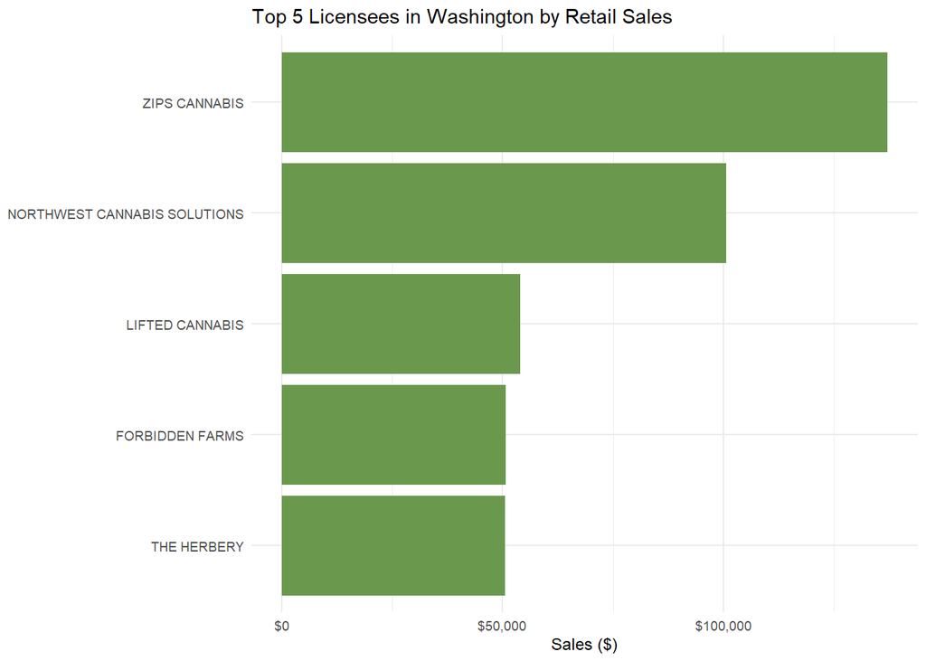

```r
wa_canna %>%
  group_by(licensee_dba) %>%
  summarise(total_sales = sum(retail_sales_amt, na.rm = TRUE)) %>%
  arrange(desc(total_sales)) %>%
  slice_head(n = 5) %>%
  ggplot(aes(reorder(licensee_dba, total_sales), total_sales)) +
  geom_col(fill = "#6A994E") +
  scale_y_continuous(labels = dollar_format()) +
  coord_flip() +
  labs(title = "Top 5 Licensees in Washington by Retail Sales", x = NULL, y = "Sales ($)") +
  theme_minimal(base_size = 9)
```

```r
# Optional: Save the plot
#ggsave("plots/top_licensees_sales.png", width = 8, height = 5)
```

🌿 What’s in a Name? (TF-IDF for Strain Names)

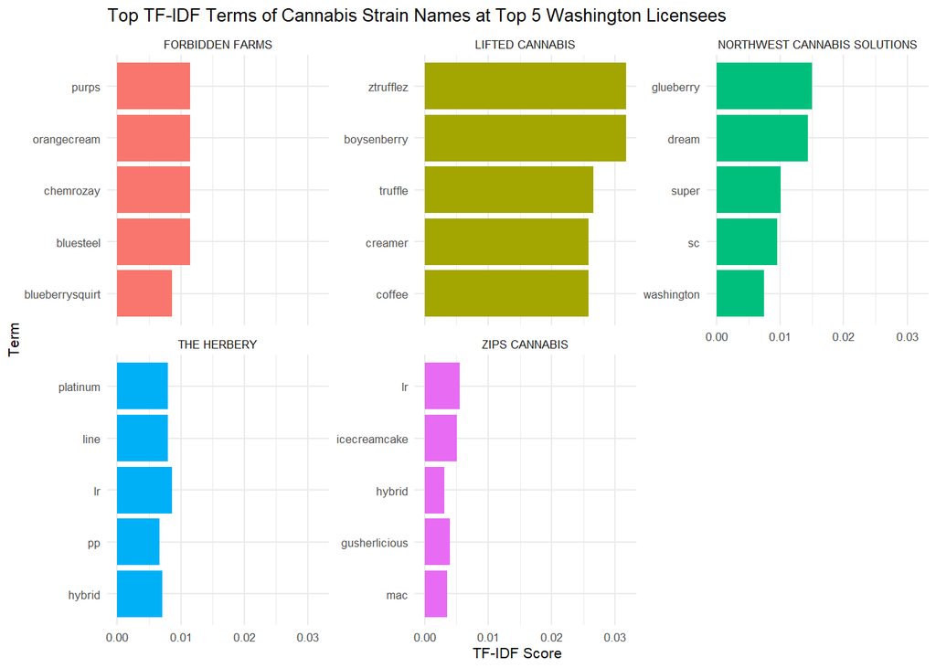

```r
# Pull the top 5 licensees by total retail sales
top_5_licensees <- wa_canna %>%
  group_by(licensee_dba) %>%
  summarise(total_sales = sum(retail_sales_amt, na.rm = TRUE)) %>%
  slice_max(total_sales, n = 5) %>%
  pull(licensee_dba)

# Filter for just those licensees
filtered_wa <- wa_canna %>%
  filter(licensee_dba %in% top_5_licensees)

# Tokenize and clean text from strain_name
tfidf_data <- filtered_wa %>%
  unnest_tokens(word, strain_name) %>%
  filter(!str_detect(word, "^\\d+$")) %>%            # Remove pure numbers
  filter(!word %in% stop_words$word) %>%             # Remove common stop words
  count(licensee_dba, word, sort = TRUE) %>%
  bind_tf_idf(word, licensee_dba, n)

# Get top 5 terms by TF-IDF per licensee
top_terms <- tfidf_data %>%
  group_by(licensee_dba) %>%
  slice_max(tf_idf, n = 5, with_ties = FALSE) %>%
  ungroup()

# Plot as faceted bar chart
ggplot(top_terms, aes(x = fct_reorder(word, tf_idf), y = tf_idf, fill = licensee_dba)) +
  geom_col(show.legend = FALSE) +
  facet_wrap(~ licensee_dba, scales = "free_y") +
  coord_flip() +
  labs(title = "Top TF-IDF Terms of Cannabis Strain Names at Top 5 Washington Licensees",
       x = "Term", y = "TF-IDF Score") +
  theme_minimal(base_size = 8)
```

```r
# Optional: Save the plot
#ggsave("plots/tfidf_terms.png", width = 8, height = 5)
```

🚬 Curious about product names? Go back and supplant “strain_name” with “product_name” and add scripts to remove special characters (-*&^%$#@?) and numbers and units (e.g. 1oz) using regex for some dank tf-idf analysis.

Because I’m kind …

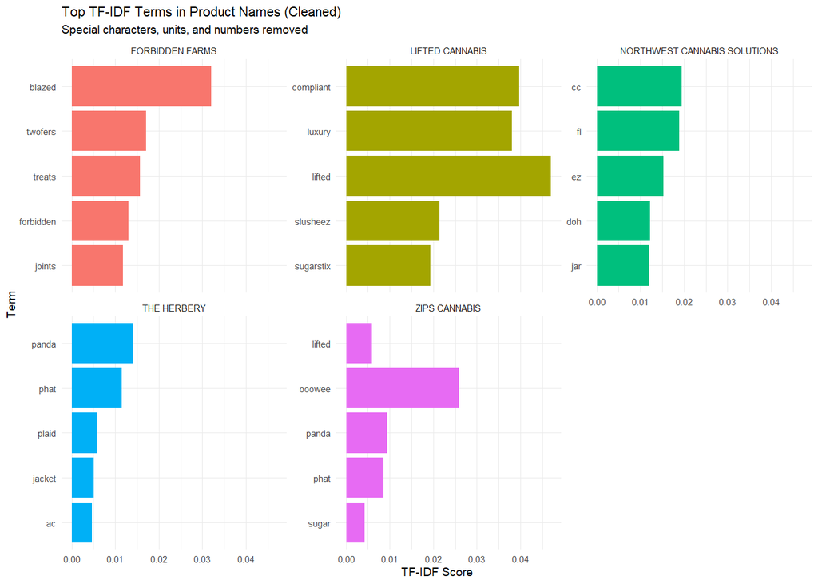

```r
# Clean + tokenize product_name
tfidf_data <- filtered_wa %>%
  mutate(product_name = str_to_lower(product_name)) %>%
  mutate(product_name = str_replace_all(product_name, "\\d+(\\.\\d+)?\\s*(g|gram|grams|oz|ounce|ounces|mg|lb|lbs)", "")) %>% # remove units like 1g, 3.5g, etc.
  mutate(product_name = str_replace_all(product_name, "[^a-zA-Z\\s]", "")) %>%  # remove special characters
  unnest_tokens(word, product_name) %>%
  filter(!word %in% stop_words$word) %>%
  filter(!word %in% stopwords::stopwords("en")) %>%  # extended stopword filter
  filter(str_detect(word, "[a-z]")) %>%              # keep only actual words
  count(licensee_dba, word, sort = TRUE) %>%
  bind_tf_idf(word, licensee_dba, n)

# Grab top 5 TF-IDF terms for each licensee
top_terms <- tfidf_data %>%
  group_by(licensee_dba) %>%
  slice_max(tf_idf, n = 5, with_ties = FALSE) %>%
  ungroup()

# Faceted bar plot
ggplot(top_terms, aes(x = fct_reorder(word, tf_idf), y = tf_idf, fill = licensee_dba)) +
  geom_col(show.legend = FALSE) +
  facet_wrap(~ licensee_dba, scales = "free_y") +
  coord_flip() +
  labs(title = "Top TF-IDF Terms in Product Names (Cleaned)",
       subtitle = "Special characters, units, and numbers removed",
       x = "Term", y = "TF-IDF Score") +
  theme_minimal(base_size = 7)
```

```r
# Optional: Save the plot
# ggsave("plots/tfidf_cleaned_terms.png", width = 8, height = 5)
```

📅 Monthly Sales: A Time Series Buzz

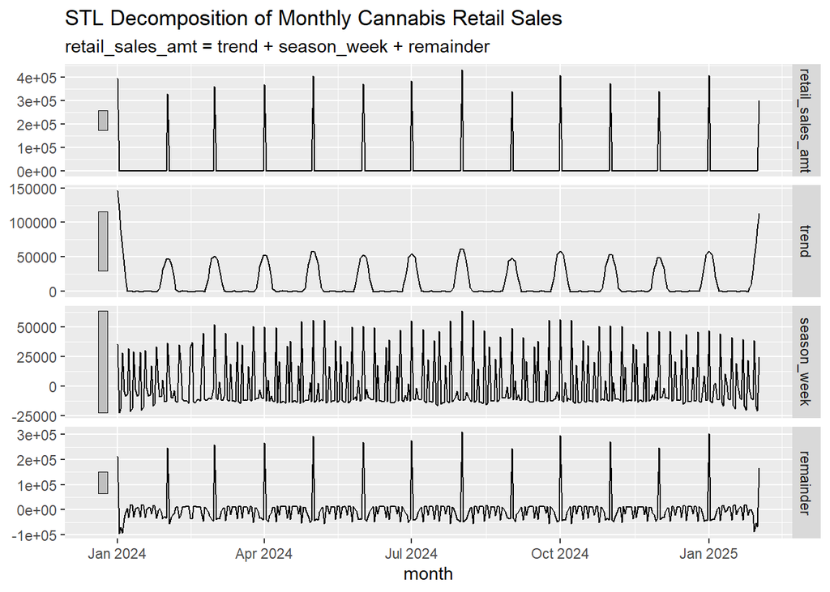

```r
# Create time series of total sales by month
monthly_sales <- wa_canna %>%
  mutate(month = floor_date(sale_date_month, unit = "month")) %>%
  group_by(month) %>%
  summarise(retail_sales_amt = sum(retail_sales_amt, na.rm = TRUE)) %>%
  ungroup()

# Convert to tsibble (time-aware tibble)
monthly_ts <- monthly_sales %>%
  as_tsibble(index = month)

# Fill any missing months (explicitly handle gaps)
monthly_ts_filled <- monthly_ts %>%
  fill_gaps(.full = TRUE) %>%
  mutate(retail_sales_amt = ifelse(is.na(retail_sales_amt), 0, retail_sales_amt))

# STL decomposition model
stl_model <- monthly_ts_filled %>%
  model(STL(retail_sales_amt))

# Extract components and plot
components <- stl_model %>%
  components()

autoplot(components) +
  labs(title = "STL Decomposition of Monthly Cannabis Retail Sales")
```

```r
# Optional: Save the plot
#ggsave("plots/stl_decomposition.png", width = 8, height = 5)
```

🧪 Decompose by Inventory Category

```r
# Aggregate by month + category/strain
# By Product Category
category_ts <- wa_canna %>%
 mutate(month = yearmonth(floor_date(sale_date_month, unit = "month"))) %>%
  group_by(month, inventory_type_category) %>%
  summarise(retail_sales_amt = sum(retail_sales_amt, na.rm = TRUE), .groups = "drop") %>%
  as_tsibble(index = month, key = inventory_type_category) %>%
  fill_gaps(retail_sales_amt = 0)

#Seasonal decomposition
# STL by Category
stl_category <- category_ts %>%
  model(STL(retail_sales_amt ~ trend(window = 7) + season(window = "periodic")))

# Debugging step
glimpse(components(stl_category))
```

```
## Rows: 99
## Columns: 7
## Key: inventory_type_category, .model [8]
## : retail_sales_amt = trend + remainder
## $ inventory_type_category <chr> "Concentrates", "Concentrates", "Concentrates"…
## $ .model                  <chr> "STL(retail_sales_amt ~ trend(window = 7) + se…
## $ month                   <mth> 2024 Jan, 2024 Feb, 2024 Mar, 2024 Apr, 2024 M…
## $ retail_sales_amt        <dbl> 135407.19, 112747.37, 106993.44, 125952.80, 12…
## $ trend                   <dbl> 120210.18, 121306.44, 122402.70, 125730.99, 12…
## $ remainder               <dbl> 15197.0070, -8559.0702, -15409.2575, 221.8108,…
## $ season_adjust           <dbl> 135407.19, 112747.37, 106993.44, 125952.80, 12…
```

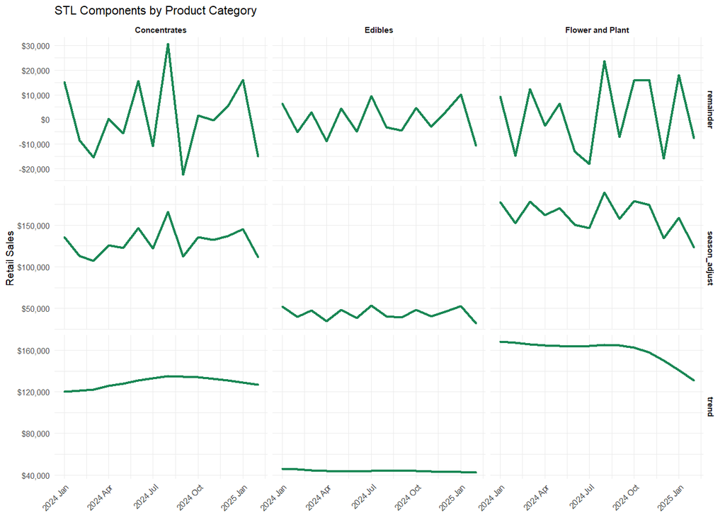

```r
# Decomposition Components
category_components <- components(stl_category) %>%
  mutate(season_adjust = retail_sales_amt - remainder)

removed_cats <- c( "Miscellaneous", "Waste/Other Materials", "Unclassified", "Mixes", "Topicals" )

# Drop model for legend clarity
category_long <- components(stl_category) %>%
  filter(!inventory_type_category %in% removed_cats) %>%
  pivot_longer(cols = c(trend, remainder, season_adjust), names_to = "component", values_to = "value")

# Remove .model from aes() inside autoplot
ggplot(category_long, aes(x = month, y = value, group = interaction(component, inventory_type_category))) +
  geom_line(color = "#198754", linewidth = 0.8, lineend = "round") +
  facet_grid(component ~ inventory_type_category, scales = "free_y") +
  scale_y_continuous(labels = dollar_format()) +
  labs(
    title = "STL Components by Product Category",
    x = NULL, y = "Retail Sales"
  ) +
  theme_minimal(base_size = 7) +
  theme(strip.text = element_text(face = "bold"),
        axis.text.x = element_text(angle = 45, hjust = 1))
```

```r
# Optional: Save the plot
#ggsave("plots/stl_decomposition_category.png", width = 8, height = 5)
```

🧪 Decompose by Strain Type

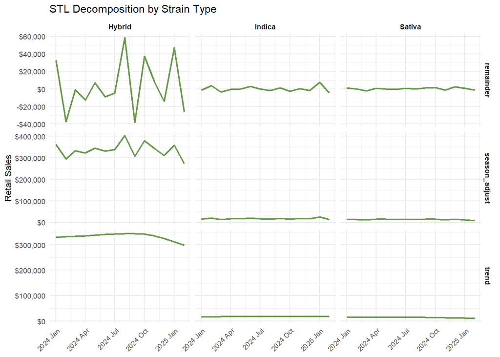

```r
# By Strain Type
strain_ts <- wa_canna %>%
  mutate(month = yearmonth(floor_date(sale_date_month, unit = "month"))) %>%
  group_by(month, strain_type) %>%
  summarise(retail_sales_amt = sum(retail_sales_amt, na.rm = TRUE), .groups = "drop") %>%
  as_tsibble(index = month, key = strain_type) %>%
  fill_gaps(retail_sales_amt = 0) %>%
  na.omit()

# Refining tool!
# Use to focus only on top 5 categories or strains
# top_strains <- wa_filtered %>%
#   count(strain_type, sort = TRUE) %>%
#   slice_head(n = 5) %>%
#   pull(strain_type)
#
# strain_ts <- strain_ts %>% filter(strain_type %in% top_strains)

# STL by Strain
stl_strain <- strain_ts %>%
  model(STL(retail_sales_amt ~ trend(window = 7) + season(window = "periodic")))

strain_components <- components(stl_strain)

strain_long <- strain_components %>%
  pivot_longer(cols = c(trend, remainder, season_adjust),
               names_to = "component",
               values_to = "value")

ggplot(strain_long, aes(x = month, y = value, group = interaction(component, strain_type))) +
  geom_line(color = "#6A994E", linewidth = 0.8) +
  facet_grid(component ~ strain_type, scales = "free_y") +
  scale_y_continuous(labels = dollar_format()) +
  labs(
    title = "STL Decomposition by Strain Type",
    x = NULL, y = "Retail Sales"
  ) +
  theme_minimal(base_size = 9) +
  theme(strip.text = element_text(face = "bold"),
        axis.text.x = element_text(angle = 45, hjust = 1))
```

```r
# Optional: Save the plot
#ggsave("plots/stl_decomposition_strain_type.png", width = 8, height = 5)
```

🌱 Forecast the Future: Category Edition

```r
# Optional: Focus on Top 5 Categories
# top_categories <- wa_filtered %>%
#   count(inventory_type_category, wt = retail_sales_amt, sort = TRUE) %>%
#   slice_head(n = 5) %>%
#   pull(inventory_type_category)
#
# category_ts <- category_ts %>%
#   filter(inventory_type_category %in% top_categories)

# For the full sample dataset
category_ts_filtered <- category_ts %>%
  group_by(inventory_type_category) %>%
  filter(n() >= 2) %>%
  ungroup()

category_model <- category_ts_filtered %>%
  model(
    ets = ETS(retail_sales_amt))
```

🌱 Forecast the Next 6 Months for each Inventory Type

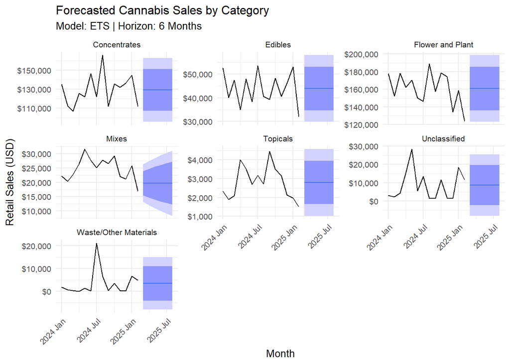

```r
# IMPORTANT! Correct the Date column format. Use category_ts_filtered instead of creating a new object. For this example, we create a new object with corrected date column.

category_forecasts <- forecast(category_model, h = "6 months")

autoplot(category_forecasts, category_ts_filtered) +
  labs(
    title = "Forecasted Cannabis Sales by Category",
    subtitle = "Model: ETS | Horizon: 6 Months",
    x = "Month",
    y = "Retail Sales (USD)"
  ) +
  scale_y_continuous(labels = dollar_format()) +
  facet_wrap(~inventory_type_category, scales = "free_y") +
  theme_minimal(base_size = 10) +
  theme(
    axis.text.x = element_text(angle = 45, hjust = 1),
    legend.position = "none"
  )
```

```r
# Optional: Save the plot
#ggsave("plots/fable_forecast_category.png", width = 8, height = 5)
```

Roll up your own take — now it’s your sesh. Repeat above steps to forecast strain name, product name, or inventory sub-category.

🌿 Bonus Nugget: Passing the TF-IDF n-grams (multi-word strain names).

In the above TF-IDF on strain name facetted plot, I noticed “Dream” and thought where’s “Blue Dream”? For this reason, I checked n-grams = 3.5 (hehe) to get longer strain names for better strain identification and quality output. Let’s see if “Super Silver Haze” shows up in the plot? You can try n = 5 to see how changing ‘n’ matters.

```r
# Load stop words
data("stop_words")

# 🔥 Bonus TF-IDF: Bigrams from strain_name
bigram_tfidf <- filtered_wa %>%
  # Create bigrams from strain_name
  unnest_tokens(bigram, strain_name, token = "ngrams", n = 3.5) %>% # when you pass a decimal, it gets silently coerced to an integer under the hood (e.g., floor(n) or as.integer(n)). It's not an issue to put 3.5, just know n = 3.

  # Remove bigrams with numbers or units (like 1g, 1oz)
  filter(!str_detect(bigram, "\\b\\d+(mg|g|oz|lb)?\\b")) %>%

  # Remove special characters
  mutate(bigram = str_replace_all(bigram, "[^a-zA-Z\\s]", "")) %>%

  # Split and remove stopwords from each part of bigram
  separate(bigram, into = c("word1", "word2"), sep = " ", fill = "right") %>%
  filter(!word1 %in% stop_words$word,
         !word2 %in% stop_words$word) %>%

  # Recombine cleaned bigram
  unite(bigram, word1, word2, sep = " ") %>%
  count(licensee_dba, bigram, sort = TRUE) %>%
  bind_tf_idf(bigram, licensee_dba, n)
```

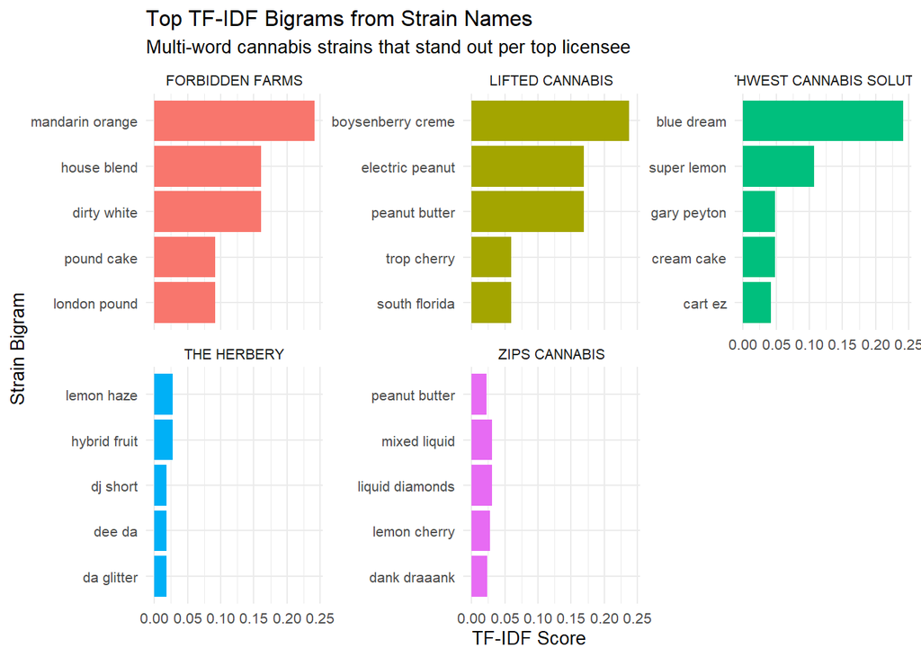

```r
# Get top 5 bigrams per licensee
top_bigrams <- bigram_tfidf %>%
  group_by(licensee_dba) %>%
  slice_max(tf_idf, n = 5, with_ties = FALSE) %>%
  ungroup()

# Plot results 💥
ggplot(top_bigrams, aes(x = fct_reorder(bigram, tf_idf), y = tf_idf, fill = licensee_dba)) +
  geom_col(show.legend = FALSE) +
  facet_wrap(~ licensee_dba, scales = "free_y") +
  coord_flip() +
  labs(
    title = "Top TF-IDF Bigrams from Strain Names",
    subtitle = "Multi-word cannabis strains that stand out per top licensee",
    x = "Strain Bigram", y = "TF-IDF Score"
  ) +
  theme_minimal(base_size = 10)
```

```r
# Optional save
#ggsave("plots/stl_strain_type_decomposition.png", width = 10, height = 6)
```

“For the Gram of It: Let’s build a comparative TF-IDF table of top terms by n-gram size for strain_name — specifically for the Top 5 WA cannabis licensees.

```r
# Helper function to compute tf-idf for any n-gram
get_tfidf_by_ngram <- function(data, n) {
  data %>%
    mutate(strain_name = str_to_lower(strain_name)) %>%
    unnest_tokens(ngram, strain_name, token = "ngrams", n = n) %>%
    filter(!str_detect(ngram, "^\\d+$")) %>% # remove pure numbers
    filter(!str_detect(ngram, "\\d")) %>%    # remove mixed digits (like 1g, 3.5g)
    filter(!str_detect(ngram, "\\b(g|mg|oz|lb|gram|grams|ml|pack)\\b")) %>%
    filter(!ngram %in% stop_words$word) %>%
    count(licensee_dba, ngram, sort = TRUE) %>%
    bind_tf_idf(ngram, licensee_dba, n) %>%
    group_by(licensee_dba) %>%
    slice_max(tf_idf, n = 5, with_ties = FALSE) %>%
    ungroup() %>%
    mutate(n_gram = paste0(n, "-gram"))
}

# Generate tf-idf results for 1, 2, 3-grams
unigrams <- get_tfidf_by_ngram(filtered_wa, n = 1)
bigrams  <- get_tfidf_by_ngram(filtered_wa, n = 2)
trigrams <- get_tfidf_by_ngram(filtered_wa, n = 3)

# Combine
ngram_results <- bind_rows(unigrams, bigrams, trigrams)

# Make a comparison table
ngram_table <- ngram_results %>%
  select(licensee_dba, n_gram, ngram, tf_idf) %>%
  arrange(licensee_dba, n_gram, desc(tf_idf)) %>%
  group_by(licensee_dba, n_gram) %>%
  mutate(rank = row_number()) %>%
  pivot_wider(names_from = n_gram, values_from = ngram) %>%
  select(licensee_dba, rank, `1-gram`, `2-gram`, `3-gram`)

# Show the table
print(ngram_table, n = 50)
```

```
## # A tibble: 75 × 5
## # Groups:   licensee_dba [5]
##    licensee_dba                  rank `1-gram`         `2-gram`         `3-gram`
##    <chr>                        <int> <chr>            <chr>            <chr>
##  1 FORBIDDEN FARMS                  1 <NA>             dirty white girl <NA>
##  2 FORBIDDEN FARMS                  2 <NA>             house blend ind… <NA>
##  3 FORBIDDEN FARMS                  3 <NA>             pound cake gela… <NA>
##  4 FORBIDDEN FARMS                  4 <NA>             face off og      <NA>
##  5 FORBIDDEN FARMS                  1 <NA>             <NA>             mandari…
##  6 FORBIDDEN FARMS                  2 <NA>             <NA>             blueber…
##  7 FORBIDDEN FARMS                  3 <NA>             <NA>             mandari…
##  8 FORBIDDEN FARMS                  4 <NA>             <NA>             orange …
##  9 FORBIDDEN FARMS                  5 <NA>             <NA>             pink ce…
## 10 FORBIDDEN FARMS                  6 <NA>             <NA>             blueber…
## 11 FORBIDDEN FARMS                  1 <NA>             <NA>             <NA>
```

[output cut: 40 more lines]

📝 Closing Thoughts

The Washington cannabis market is a hotbox of trends and data-rich opportunities. Whether you’re curious about strain branding, retailer dynamics, or market timing — even this small sample dataset offers plenty of insight for kind-folks to roll up.

Stay lit 🔥 — and don’t forget: legalize data analysis.

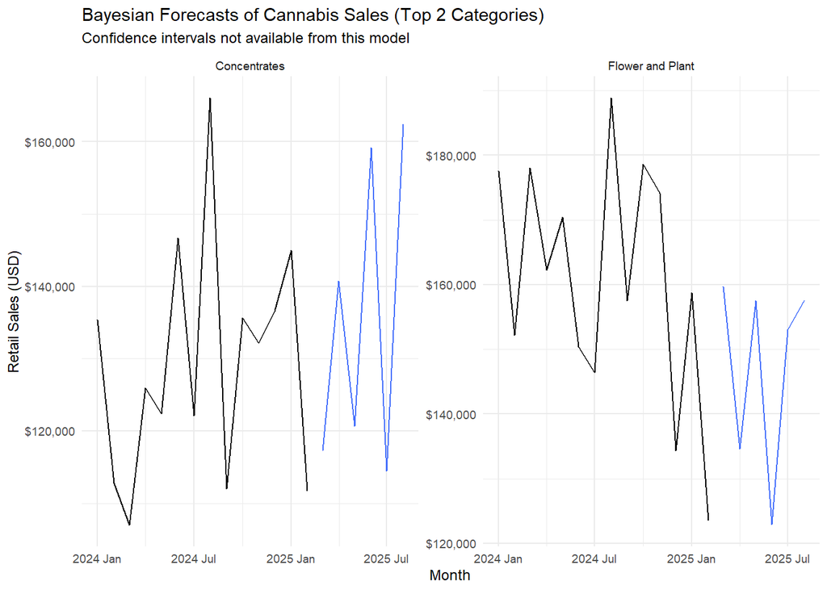

```r
# Identify top 2 selling product categories
top_categories <- wa_canna %>%
  count(inventory_type_category, wt = retail_sales_amt, sort = TRUE) %>%
  slice_head(n = 2) %>%
  pull(inventory_type_category)

# Filter time series for just those categories
category_ts_bayes <- category_ts %>%
  filter(inventory_type_category %in% top_categories)

# Clean for valid time series modeling (at least 2 non-zero entries)
category_ts_bayes_clean <- category_ts_bayes %>%
  group_by(inventory_type_category) %>%
  filter(sum(!is.na(retail_sales_amt) & retail_sales_amt > 0) >= 2) %>%
  ungroup()

# Fit NNETAR model (Bayesian-like neural net autoregression)
category_bayes_model <- category_ts_bayes_clean %>%
  model(
    bayes = NNETAR(retail_sales_amt)
  )

# Forecast next 6 months with confidence intervals
category_forecasts <- forecast(category_bayes_model, h = "6 months", level = c(80, 95))

# Check if confidence levels exist in forecast
if (".level" %in% colnames(category_forecasts)) {

  # Convert forecast to wider format for plotting ribbons
  plot_data <- category_forecasts %>%
    filter(.model == "bayes") %>%   # Optional if other models exist
    as_tibble() %>%
    filter(.level %in% c(80, 95)) %>%
    select(month, inventory_type_category, .mean, .lower, .upper, .level) %>%
    pivot_wider(
      names_from = .level,
      values_from = c(.lower, .upper),
      names_glue = "{.value}_{.level}"
    )

  # Bring in historical data
  hist_data <- category_ts_bayes_clean %>%
    select(month, inventory_type_category, retail_sales_amt)

  # Plot forecast with ribbons
  ggplot(plot_data, aes(x = month, y = .mean)) +
    geom_ribbon(aes(ymin = .lower_95, ymax = .upper_95), fill = "#B0E0E6", alpha = 0.3) +
    geom_ribbon(aes(ymin = .lower_80, ymax = .upper_80), fill = "#ADD8E6", alpha = 0.5) +
    geom_line(color = "#1f77b4", size = 1) +
    geom_line(data = hist_data, aes(x = month, y = retail_sales_amt), color = "darkgreen") +
    facet_wrap(~inventory_type_category, scales = "free_y") +
    scale_y_continuous(labels = dollar_format()) +
    labs(
      title = "Bayesian Forecasts of Cannabis Sales (Top 2 Categories)",
      subtitle = "Forecasts with 80% and 95% Confidence Intervals",
      x = "Month", y = "Retail Sales (USD)"
    ) +
    theme_minimal(base_size = 9)

} else {
  # Fallback for models that do NOT support CIs (e.g., NNETAR in some settings)
  autoplot(category_forecasts, category_ts_bayes_clean) +
    facet_wrap(~inventory_type_category, scales = "free_y") +
    labs(
      title = "Bayesian Forecasts of Cannabis Sales (Top 2 Categories)",
      subtitle = "Confidence intervals not available from this model",
      x = "Month", y = "Retail Sales (USD)"
    ) +
    scale_y_continuous(labels = dollar_format()) +
    theme_minimal(base_size = 9) +
    theme(legend.position = "none")
}
```

🌿 Ultimate Cannabis Vibe Recap: